# Expressed Variant Reporting

Brandon Michael Blobner, Jenny Leopoldina Smith, and Ahmad Al Khleifat

2021-02-17

# 1 About The Test: Variant Detection from RNA-seq

[figure not shown]

snpReportR

Patient details:

| Information | Value |
| --- | --- |
| Name: | Jane Doe |
| DOB: | 01/01/1900 |
| Sex: | F |
| Sample Type: | RNA |

Test ordered by:

| Information | Value |
| --- | --- |
| Name: | Dr.X |
| Doctor identification number: | 12345 |
| Hospital: | NCI |

This document will help you to understand the more important findings from a gene variant screening. The common definitions of the type of genetic variants (mutations) are described in the figure and in the table in section `Chromosome and Gene Vizualization of Mutations`.

While a variant may have been detected, the associations with the variant are not perfectly causal and their complex interactions between biology and the environment.

# 2 About the Dataset

|  | Number | Type | Description |
| --- | --- | --- | --- |
| AC | A | Integer | Allele count in genotypes for each ALT allele in the same order as listed |
| AF | A | Float | Allele Frequency for each ALT allele in the same order as listed |
| AN | 1 | Integer | Total number of alleles in called genotypes |
| BaseQRankSum | 1 | Float | Z-score from Wilcoxon rank sum test of Alt Vs. Ref base qualities |
| DP | 1 | Integer | Approximate read depth; some reads may have been filtered |
| ExcessHet | 1 | Float | Phred-scaled p-value for exact test of excess heterozygosity |
| FS | 1 | Float | Phred-scaled p-value using Fisher's exact test to detect strand bias |
| InbreedingCoeff | 1 | Float | Inbreeding coefficient as estimated from the genotype likelihoods per-sample when compared against the Hardy-Weinberg expectation |
| MLEAC | A | Integer | Maximum likelihood expectation (MLE) for the allele counts (not necessarily the same as the AC) for each ALT allele in the same order as listed |
| MLEAF | A | Float | Maximum likelihood expectation (MLE) for the allele frequency (not necessarily the same as the AF) for each ALT allele in the same order as listed |

[output cut: 50 more lines]

Table 1. Column names and Descriptions

*In addition there are functional annotations for the variants per transcript from snpEFF. These include:*

- “Annotation_Impact”
- “Feature_Type”
- “Transcript_BioType”
- “Rank”
- “HGVS.c”
- “HGVS.p”
- “cDNA.pos/cDNA.length”
- “CDS.pos/CDS.length”
- “AA.pos/AA.length”
- “Distance”

*The top variants were ranked by the following attributes:*

- FATHMM predicted pathogenicty or splice adjacent
- genes with larger number of SNVs prioritized
- high or moderate impact on the structure of the gene
- CADD Score/Polyphen Score (not done yet)

|  | FATHMM | SPLICEADJ | Annotation_Impact_1 | Number_of_Genes |
| --- | --- | --- | --- | --- |
| 1 | NEUTRAL | 8 | LOW | 1 |
| 2 | PATHOGENIC |  | MODERATE | 8 |
| 3 |  | 3 | MODIFIER | 1 |
| 4 |  | 7 | MODIFIER | 1 |
| 5 |  | 10 | MODIFIER | 1 |

# 3 HumanMine Annotation for Further Results

```
## Retrieving Annotations for Genes.
```

```
## [1] "PRRC2C"          "RNPEP"           "GBE1"            "ARSE"
## [5] "PMF1,PMF1-BGLAP"
```

|  | ARSE.Top.Expression | GBE1.Top.Expression | PMF1,PMF1-BGLAP.Top.Expression | PRRC2C.Top.Expression | RNPEP.Top.Expression |
| --- | --- | --- | --- | --- | --- |
| 1 | ovary | lymph node | dendritic cells | heart muscle | heart muscle |
| 2 | fallopian tube | monocytes | fallopian tube | skeletal muscle | duodenum |
| 3 | liver | B-cells | cerebral cortex | parathyroid gland | fallopian tube |
| 4 | kidney | adipose tissue | prostate | testis | small intestine |
| 5 | endometrium | adrenal gland | thyroid gland | lymph node | rectum |

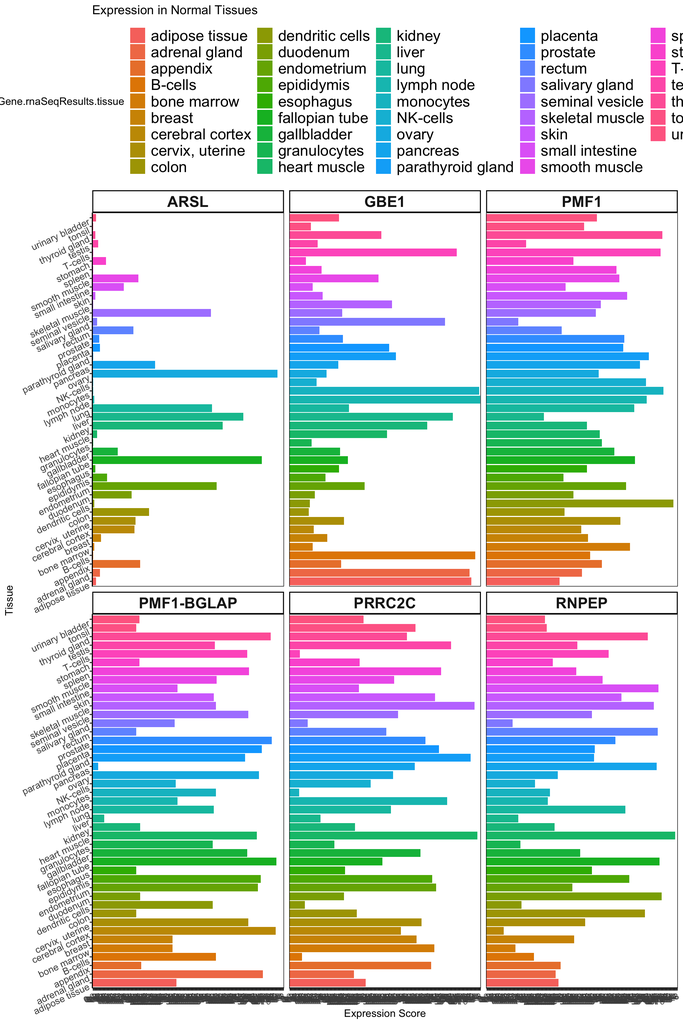

Expression of Genes with identified variants/SNVs in Normal Tissues.

# 4 Results Table

Included here are two tables for different gene types. Coding refers to genes that produce proteins, while non-coding refers to genes which do get utilized to produce proteins.

## 4.1 Coding Genes

|  | GENE | Number_SNVs_per_Gene | COSMIC_ID | rsID | CHROM | POS | ID | REF | ALT | FATHMM | SPLICEADJ | TISSUE | TUMOR | Annotation_1 | Annotation_Impact_1 | Feature_Type_1 | Transcript_BioType_1 | coding_DNA_change_1 | protein_change_1 |
| --- | --- | --- | --- | --- | --- | --- | --- | --- | --- | --- | --- | --- | --- | --- | --- | --- | --- | --- | --- |
| 1 | PRRC2C | 2 | COSV58904826 | rs10913157 | chr1 | 171517773 |  | G | A | PATHOGENIC |  | large_intestine | carcinoma_--_adenocarcinoma | missense_variant | MODERATE | transcript | Coding | c.703G&gt;A | p.Ala235Thr |
| 2 | RNPEP | 2 | COSV55241000 | rs3820439 | chr1 | 202004437 |  | G | A | PATHOGENIC |  | haematopoietic_and_lymphoid_tissue | haematopoietic_neoplasm_--_acute_myeloid_leukaemia | missense_variant | MODERATE | transcript | Coding | c.1735G&gt;A | p.Val579Ile |
| 3 | GBE1 | 2 | COSV70097964 | rs2229519 | chr3 | 81648979 |  | T | C | PATHOGENIC |  | soft_tissue | rhabdomyosarcoma_--_embryonal | missense_variant | MODERATE | transcript | Coding | c.568A&gt;G | p.Arg190Gly |
| 4 | ARSE | 2 | COSV66965335 | rs35143646 | chrX | 2938114 |  | C | T | PATHOGENIC |  | lung | carcinoma_--_NS | missense_variant | MODERATE | transcript | Coding | c.1345G&gt;A | p.Gly449Ser |
| 5 | PMF1,PMF1-BGLAP | 1 | COSV60771642 | rs1052067 | chr1 | 156236330 |  | G | A | PATHOGENIC |  | lung | carcinoma_--_NS | missense_variant | MODERATE | transcript | Coding | c.417G&gt;A | p.Met139Ile |
| 6 | CINP | 1 | COSV53736670 | rs7011 | chr14 | 102348705 |  | C | T | PATHOGENIC |  | lung | carcinoma_--_NS | missense_variant | MODERATE | transcript | Coding | c.491G&gt;A | p.Arg164His |
| 7 | CPPED1 | 1 | COSV55498060 | rs1713480 | chr16 | 12665109 |  | T | C | PATHOGENIC |  | lung | carcinoma_--_NS | missense_variant | MODERATE | transcript | Coding | c.722A&gt;G | p.Lys241Arg |
| 8 | EMP3 | 1 | COSV99035516 | rs4893 | chr19 | 48330351 |  | A | G | PATHOGENIC |  | lung | carcinoma_--_non_small_cell_carcinoma | missense_variant | MODERATE | transcript | Coding | c.373A&gt;G | p.Ile125Val |
| 9 | VCP | 2 | COSV62720360 | rs684562 | chr9 | 35060305 |  | T | C | NEUTRAL | 8 | lung | carcinoma_--_NS | splice_region_variant&amp;intron_variant | LOW | transcript | Coding | c.1695+8A&gt;G |  |
| 10 | C17orf99 | 1 |  |  | chr17 | 78158204 |  | G | A |  | 7 |  |  | intron_variant | MODIFIER | transcript | Coding | c.71-2751G&gt;A |  |

## 4.2 Non-Coding Genes

|  | GENE | Number_SNVs_per_Gene | COSMIC_ID | rsID | CHROM | POS | ID | REF | ALT | FATHMM | SPLICEADJ | TISSUE | TUMOR | Annotation_1 | Annotation_Impact_1 | Feature_Type_1 | Transcript_BioType_1 | coding_DNA_change_1 | protein_change_1 |
| --- | --- | --- | --- | --- | --- | --- | --- | --- | --- | --- | --- | --- | --- | --- | --- | --- | --- | --- | --- |

# 5 Chromosome and Gene Vizualization of Mutations

Table 6. Types of Expressed Variants

| Type | Description |
| --- | --- |
| coding: | Mutation is within a coding region |
| 5prime_UTR: | Mutation is within 5’ untranslated region |
| 3prime_UTR: | Mutation is with 3’ untranslated region |
| introninc: | Mutation is with an intron region |
| splice: | Mutation is within proximity to a splice-site. |
| synonymous_variant: | Synonymous variant is a mutation in an exon that results in same amino acid (changed codon) |
| missense_variant: | Missense variant is a mutation in an exon that results in a different amino acid (changed codon) |
| start/stop: | Mutation is within a start/stop codon. |

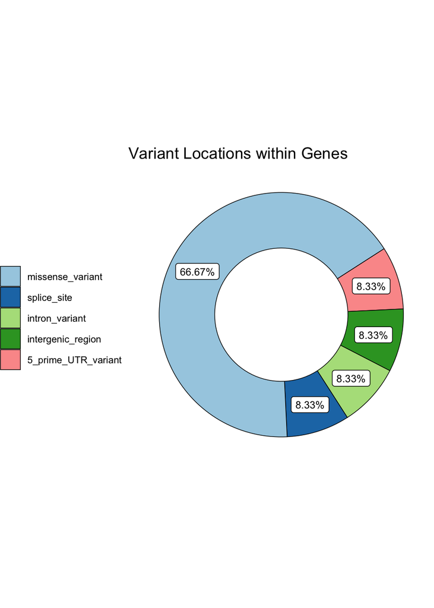

Figure 1. Percentage of different types of mutations identified.

```
## [1] "chr1" "chr3" "chrX"
```

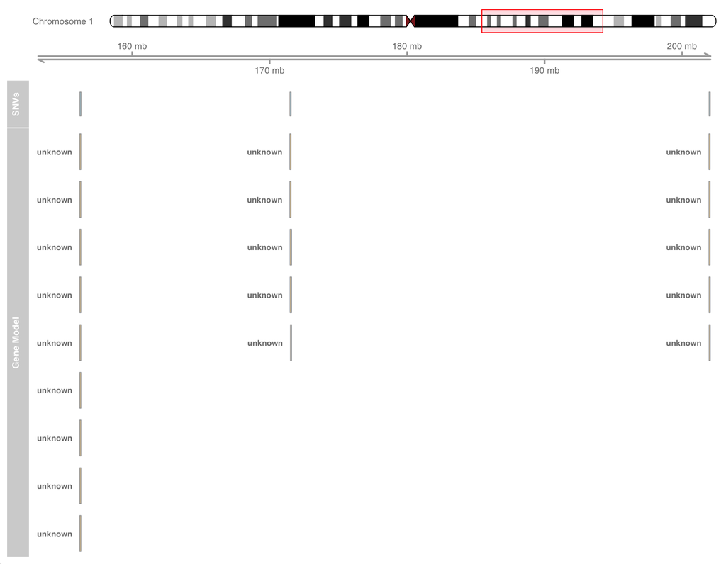

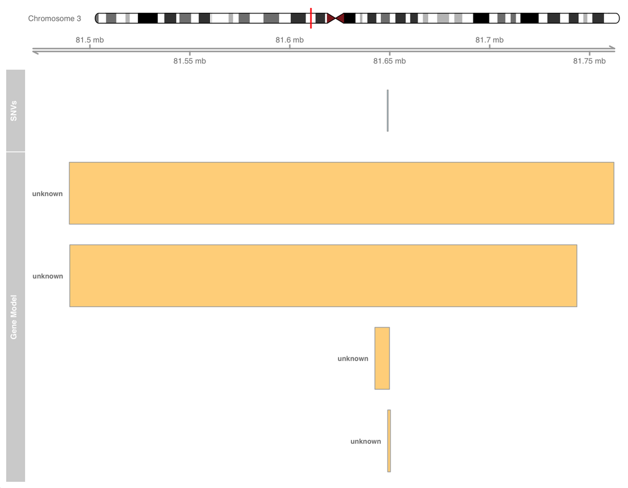

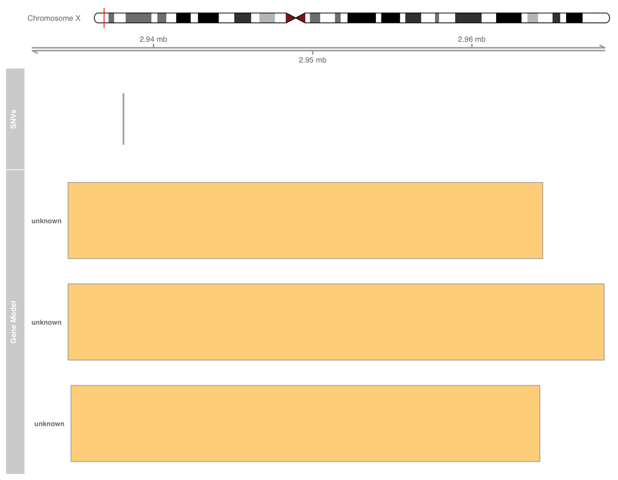

```r
# Add Lollipop plot - interactive
```